# Sprawozdanie z projektu 1

# Temat projektu

Projekt składa się z trzech problemów, które opierają się na obróbce i analizie danych, a następnie wyciągnęciu stosownych wniosków. Dwa pierwsze problemy dotyczyły klimatu, tj. zmian pogody w okresie ferii zimowych na przestrzeni lat, zaś problem trzeci odnosił się do zbadania sygnału z detektora promieniowania gamma.

# Zbiór danych

Do realizacji zadania wykorzystano dwa zbiory danych. W przypadku dwóch pierwszych zadań był to ogólnodostępny zbiór danych dotyczących pogody w ciągu roku na przestrzeni kilkudziesięciu lat (od 1951 do 2023). Zbiór ten zawierał nastęujace informacje:

Kod stacji 9  
Nazwa stacji 30  
Rok 4  
Miesiąc 2  
Dzień 2  
Maksymalna temperatura dobowa [°C] 6/1  
Status pomiaru TMAX 1  
Minimalna temperatura dobowa [°C] 6/1  
Status pomiaru TMIN 1  
Średnia temperatura dobowa [°C] 8/1  
Status pomiaru STD 1  
Temperatura minimalna przy gruncie [°C] 6/1  
Status pomiaru TMNG 1  
Suma dobowa opadów [mm] 8/1  
Status pomiaru SMDB 1  
Rodzaj opadu [S/W/ ] 1  
Wysokość pokrywy śnieżnej [cm] 5  
Status pomiaru PKSN 1

Status “8” brak pomiaru  
Status “9” brak zjawiska

Do realizacji zadania trzeciego skorzystano z udostępnionego zbioru danych z sygnałem z detektora promieniowania gamma. Zbiór ten zawierał kolejno mierzone implusy (czas próbkowania 50MHz) obarczone pewnym szumem.

# Problem 1

Problem pierwszy polegał na wyborze trzech odległych lokalizacji i czytelnym zobrazowaniu występujących między nimi różnic ze względu na maksymalną dobową temperaturę oraz zmiany temperatury dla kolejnych dni. W podpunkcie drugim należało wybrać jedną z lokalizcji i zbadać rozkład wahań temperatur między 2 następuiącymi po sobie dniami , a następnie ocenić jego dopasowanie do rozkładu normalnego oraz oszacować tempetarurę na kolejny dzień, znając pogodę w dniu poprzednim.

## Zadanie 1a

### Treść

Proszę wybrać trzy odległe lokalizacje pomiarów i czytelnie zobrazować występujące między nimi różnice ze względu na (3 różne analizy):  
1. Maksymalne dobowe temperatury (gdzie było zimniej?)  
2. Wahania maksymalnej dobowej temperatury z dnia na dzień (gdzie było stabilniej?).

### Rozwiązanie

Załadowano wymagane pakiety i dane

Zgodnie z poleceniem do realizacji problemu 1 wykorzystano jedynie dane z okresu ferii zimowych - styczeń i luty roku 2022 oraz styczeń i luty roku 2023.

Pobrane pliki do tego zadania to: k_d_01_2022, k_d_02_2022, k_d_01_2023, k_d_02_2023

Zaimportowano powyższe pliki i wczytano pliki CSV

Pobrane i uporządkowane dane do zadania 1 zapisano w pliku CSV o nazwie ferie.csv.

```r
write.csv(df_merged, "ferie.csv", row.names = FALSE)
```

Do danych dodano nową kolumnę ‘Data’ w formacie rok-miesiąc-dzień. Fragment tabeli z danymi pokazano poniżej:

|  | Numer | Lokalizacja | Rok | Miesiac | Dzien | Tmax | Status.pomiaru.Tmax | Tmin | Status.pomiaru.Tmin | Tavg | Status.pomiaru.Tavg | TMNG | Status.pomiaru.TMNG | SMDB | Status.pomiaru.SMDB | Rodzaj.opadu...S.W... | PKSN | Status.pomiaru.PKSN | Data |
| --- | --- | --- | --- | --- | --- | --- | --- | --- | --- | --- | --- | --- | --- | --- | --- | --- | --- | --- | --- |
| 1 | 249180010 | PSZCZYNA | 2022 | 1 | 1 | 11.8 | NA | 7.7 | NA | 9.3 | NA | 1.0 | NA | 5.8 | NA | W | 0 | 9 | 2022-01-01 |
| 2 | 249180010 | PSZCZYNA | 2022 | 1 | 2 | 12.3 | NA | 4.7 | NA | 7.9 | NA | 0.5 | NA | 0.2 | NA | W | 0 | 9 | 2022-01-02 |
| 3 | 249180010 | PSZCZYNA | 2022 | 1 | 3 | 11.3 | NA | 6.6 | NA | 8.4 | NA | 2.5 | NA | 8.8 | NA | W | 0 | 9 | 2022-01-03 |
| 4 | 249180010 | PSZCZYNA | 2022 | 1 | 4 | 11.3 | NA | 4.2 | NA | 8.1 | NA | 2.0 | NA | 2.5 | NA | W | 0 | 9 | 2022-01-04 |
| 5 | 249180010 | PSZCZYNA | 2022 | 1 | 5 | 11.5 | NA | 0.8 | NA | 4.4 | NA | -0.5 | NA | 2.2 | NA | W | 0 | 9 | 2022-01-05 |
| 6 | 249180010 | PSZCZYNA | 2022 | 1 | 6 | 2.9 | NA | -1.7 | NA | 0.2 | NA | -4.4 | NA | 1.1 | NA | S | 0 | 9 | 2022-01-06 |

### Problem 1a - Maksymalne dobowe temperatury

Do realizacji tego podpunktu wybrano następujace miejscowości: Radziechowy, Jarocin oraz Olecko.

Olecko – miasto w północno-wschodniej części Polski w województwie warmińsko-mazurskim, powiecie oleckim, nad rzeką Legą i Jeziorem Oleckim Wielkim na Mazurach.

Jarocin – miasto w środkowo-zachodniej Polsce, w województwie wielkopolskim, siedziba powiatu jarocińskiego i gminy Jarocin.

Radziechowy – wieś w Polsce położona w województwie śląskim, w powiecie żywieckim, w gminie Radziechowy-Wieprz.

Kolejnym etapem był podział zbioru danych na te z 2022 i 2023 roku. Przygotowane do analizy ramki danych wyglądają następująco:

|  | Lokalizacja | Data | Tmax |
| --- | --- | --- | --- |
| 1 | RADZIECHOWY | 2022-01-01 | 12.8 |
| 2 | RADZIECHOWY | 2022-01-02 | 12.3 |
| 3 | RADZIECHOWY | 2022-01-03 | 9.6 |
| 4 | RADZIECHOWY | 2022-01-04 | 9.0 |
| 5 | RADZIECHOWY | 2022-01-05 | 8.3 |
| 6 | RADZIECHOWY | 2022-01-06 | 3.8 |
| 7 | RADZIECHOWY | 2022-01-07 | 2.2 |
| 8 | RADZIECHOWY | 2022-01-08 | -0.7 |
| 9 | RADZIECHOWY | 2022-01-09 | 4.3 |
| 10 | RADZIECHOWY | 2022-01-10 | 1.4 |

[output cut: 160 more lines]

|  | Lokalizacja | Data | Tmax |
| --- | --- | --- | --- |
| 171 | RADZIECHOWY | 2023-01-01 | 15.3 |
| 172 | RADZIECHOWY | 2023-01-02 | 14.8 |
| 173 | RADZIECHOWY | 2023-01-03 | 8.8 |
| 174 | RADZIECHOWY | 2023-01-04 | 8.6 |
| 175 | RADZIECHOWY | 2023-01-05 | 10.3 |
| 176 | RADZIECHOWY | 2023-01-06 | 12.0 |
| 177 | RADZIECHOWY | 2023-01-07 | 10.7 |
| 178 | RADZIECHOWY | 2023-01-08 | 11.3 |
| 179 | RADZIECHOWY | 2023-01-09 | 11.1 |
| 180 | RADZIECHOWY | 2023-01-10 | 8.8 |

[output cut: 167 more lines]

##### Wykres pudełkowy dla temperatur podczas ferii zimowych - styczeń i luty rok 2022

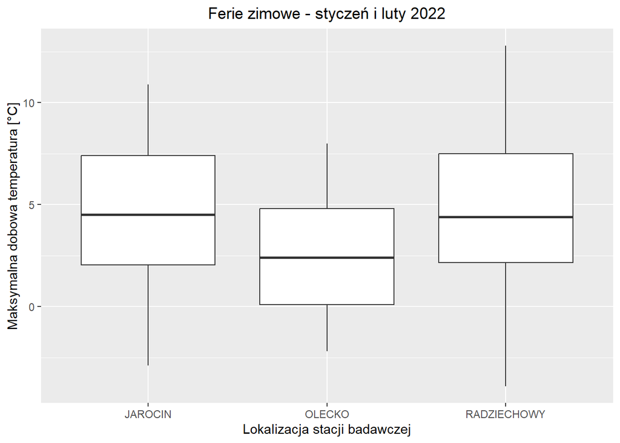

Wartość średnia, maksymalna i minimalna dla maksymalnych temperatur dla wybranych miejscowości:

| Lokalizacja | mean_temp | max_temp | min_temp | amplituda |
| --- | --- | --- | --- | --- |
| JAROCIN | 4.6 | 10.9 | -2.9 | 13.8 |
| OLECKO | 2.5 | 8.0 | -2.2 | 10.2 |
| RADZIECHOWY | 4.8 | 12.8 | -3.9 | 16.7 |

Rozkład kwartylowy w Jarocinie:

```
##    0%   25%   50%   75%  100%
## -2.90  2.05  4.50  7.40 10.90
```

Temperatura w przedziale od -2.9 °C (0 percentyl) do 10.9 °C (100 percentyl). Mediana wynosi 4.5 °C

Rozkład kwartylowy w Olecku:

```
##   0%  25%  50%  75% 100%
## -2.2  0.1  2.4  4.8  8.0
```

Temperatura w przedziale od -2.2 °C do 8 °C. Mediana wynosi 2.4 °C

Rozkład kwartylowy w Radziechowach:

```
##    0%   25%   50%   75%  100%
## -3.90  2.15  4.40  7.50 12.80
```

Temperatury w przedziale od -3.9°C do 12.8°C. Mediana wynosi 4.4°C.

**WNIOSKI:**

Najwyższą dobową temperaturę odnotowano kolejno w Radziechowach - 12.8°C, Jarocinie - 10.9°C, Olecku - 8°C, najniższa zaś kolejno w Radziechowach - -3.9°C, Jarocinie - -2.9°C, Olecku - -2.2°C.

Największa ampltudę temperatury w okresie ferii zanotowano kolejno w Radziechowach - 16.7°C, Jarocinie - 13.8°C, Olecku - 10.2°C

##### Wykres pudełkowy dla temperatur podczas ferii zimowych - styczeń i luty rok 2023

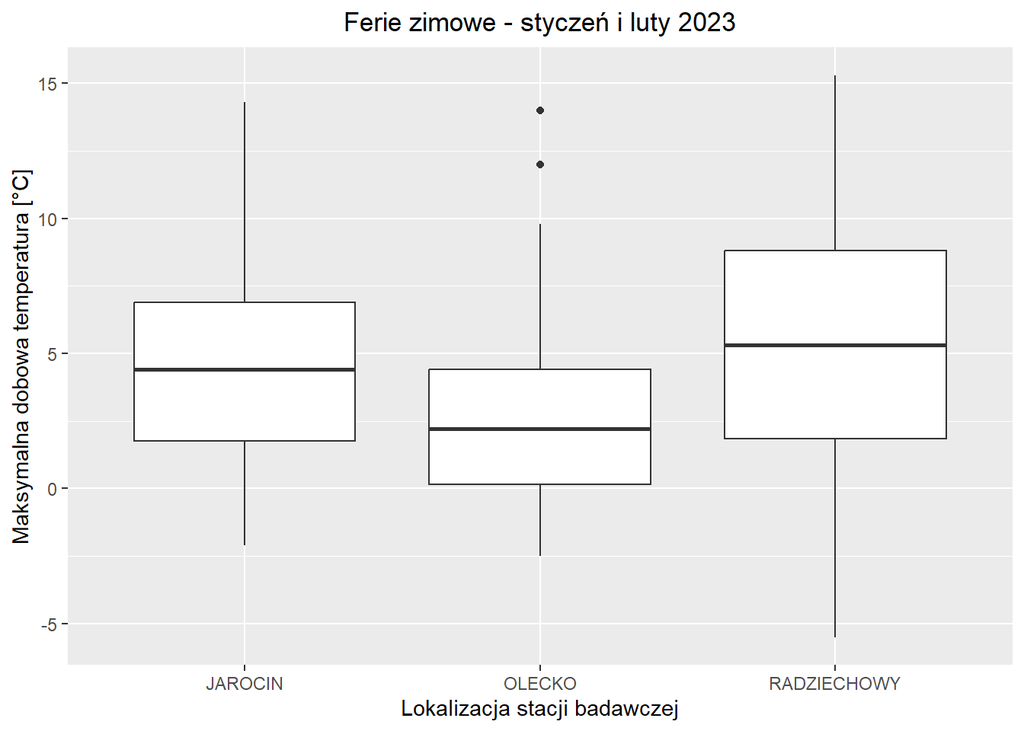

Wartość średnia, maksymalna i minimalna tempetratury

| Lokalizacja | mean_temp | max_temp | min_temp | amplituda |
| --- | --- | --- | --- | --- |
| JAROCIN | 4.7 | 14.3 | -2.1 | 16.4 |
| OLECKO | 2.6 | 14.0 | -2.5 | 16.5 |
| RADZIECHOWY | 5.2 | 15.3 | -5.5 | 20.8 |

Rozkład kwartylowy w Jarocinie:

```
##    0%   25%   50%   75%  100%
## -2.10  1.75  4.40  6.90 14.30
```

Temperatura w przedziale od -2.1 °C (0 percentyl) do 14.3 °C (100 percentyl). Mediana wynosi 4.4 °C

Rozkład kwartylowy w Olecku:

```
##    0%   25%   50%   75%  100%
## -2.50  0.15  2.20  4.40 14.00
```

Temperatura w przedziale od -2.5 °C do 14.00 °C. Mediana wynosi 2.2 °C

Rozkład kwartylowy w Radziechowach:

```
##    0%   25%   50%   75%  100%
## -5.50  1.85  5.30  8.80 15.30
```

Temperatura w przedziale od -5.5 °C do 15.3 °C. Mediana wynosi 5.3 °C

**WNIOSKI:**

Najwyższą dobową temperaturę odnotowano kolejno w Radziechowach - 15.3°C, Jarocinie - 14.3°C, Olecku - 14°C, najniższa zaś kolejno w Radziechowach - -5.5°C, Olecku - -2.5°C, Jarocinie - -2.1°C.

Największa ampltudę temperatury w okresie ferii zanotowano kolejno w Radziechowach - 20.8°C, Olecku - 16.5°C, Jarocinie - 16.4°C.

### Porównanie temperatur w roku 2022 i 2023

#### Jarocin

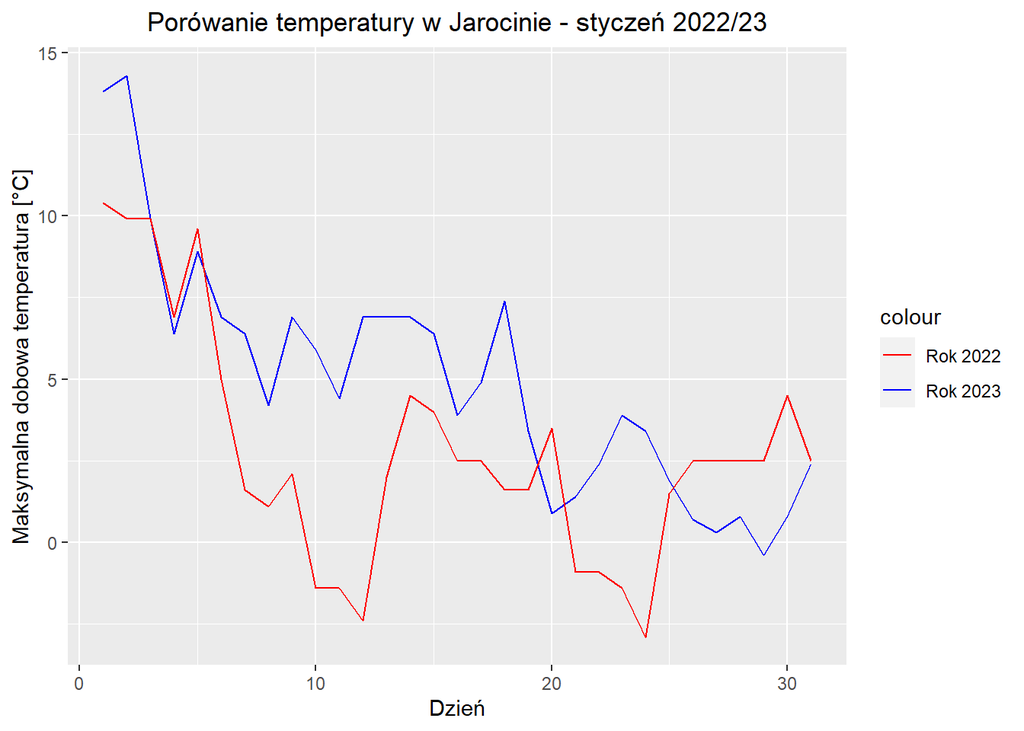

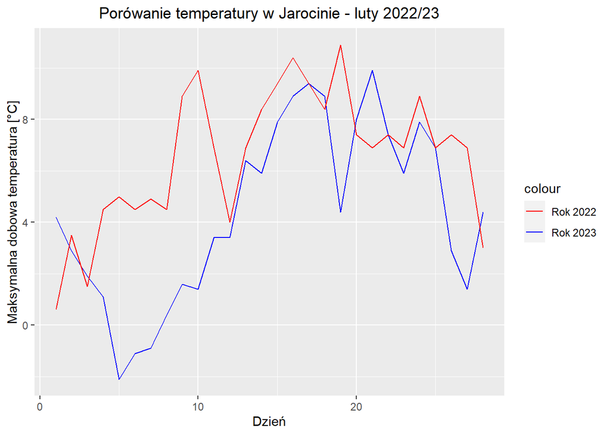

#### Olecko

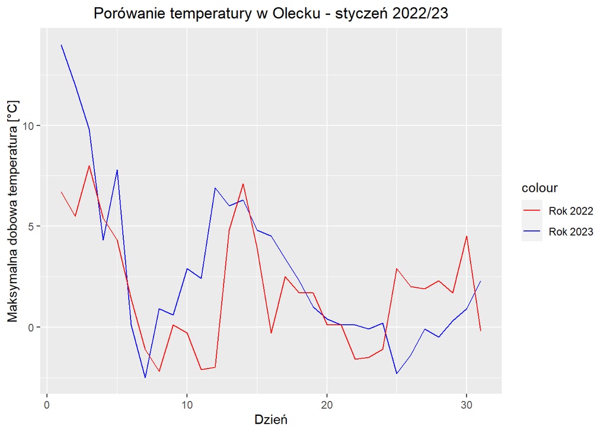

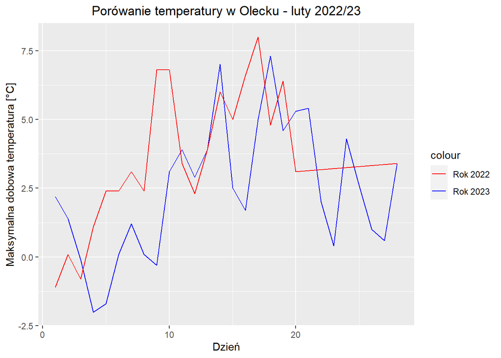

#### Radziechowice

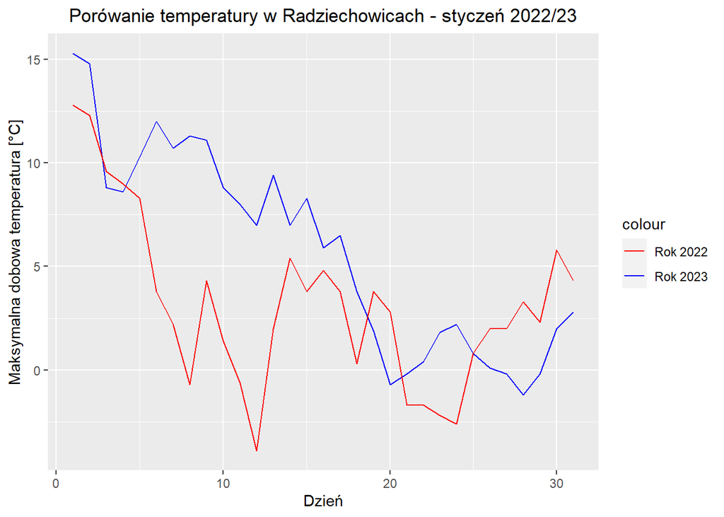

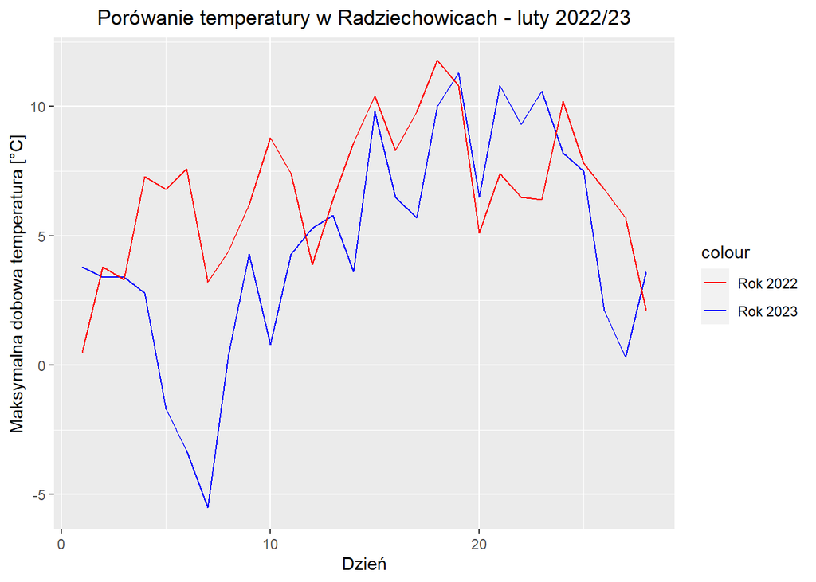

#### Maksymalne dobowe temperatury - sumaryczne zestawienie ferii 2022/2023

Na poniższym wykresie pudełkowym zestawiono ze sobą wszystkie maksymalne temperatury zebrane w okresie ferii zimowych dla opisywanych wyżej miejscowości w roku 2022/23 (okres 4 miesięcy) . W tym przypadku zastosowano inne narzędzie do rysowania, mianowicie podstawową funkcję z pakietu R pozwalającą na rysowanie wykresów pudełkowych - boxplot.

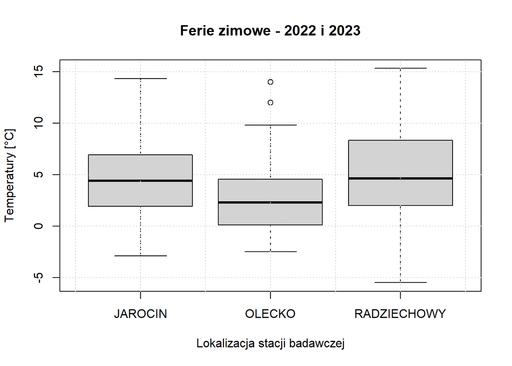

Wartość średnia, maksymalna i minimalna tempetratury

| Lokalizacja | mean_temp | max_temp | min_temp | amplituda |
| --- | --- | --- | --- | --- |
| JAROCIN | 4.6 | 14.3 | -2.9 | 17.2 |
| OLECKO | 2.6 | 14.0 | -2.5 | 16.5 |
| RADZIECHOWY | 5.0 | 15.3 | -5.5 | 20.8 |

Rozkład kwartylowy w Jarocinie:

```
##   0%  25%  50%  75% 100%
## -2.9  1.9  4.4  6.9 14.3
```

Temperatura oscyluje od -2.9 °C do 14.3 °C. Mediana wynosi 4.4 °C

Rozkład kwartylowy w Olecku:

```
##    0%   25%   50%   75%  100%
## -2.50  0.10  2.30  4.55 14.00
```

Temperatura oscyluje od -2.5 °C do 14.00 °C. Mediana wynosi 2.3 °C

Rozkład kwartylowy w Radziechowach:

```
##   0%  25%  50%  75% 100%
## -5.5  2.0  4.6  8.3 15.3
```

Temperatury oscyluje od -5.5°C do 15.3°C. Mediana wynosi 4.6°C.

**WNIOSKI:**

Najwyższą dobową temperaturę odnotowano kolejno w Radziechowach - 15.3°C, Jarocinie - 14.3°C, Olecku - 14°C, najniższa zaś kolejno w Radziechowach - -5.5°C, Jarocinie - -2.9°C, Olecku - -2.5°C.

Największy rozstęp dla maksymalnych temperatur został odnotowany w Radziechowach : 6.3°C, najmniejszy z kolei w Olecku: 4.45°C.

### Problem 1b - Wahania maksymalnej dobowej temperatury

#### Ferie zimowe - styczeń i luty rok 2022

W poniższej tabeli zestawiono różnicę maksymalnej dobowej temperatury na przestrzeni kolejnych dni w okresie ferii zimowych w roku 2022 dla poszczególnych miejscowości.

| Lokalizacja | Data | Tmax | Tdiff |
| --- | --- | --- | --- |
| JAROCIN | 2022-01-01 | 10.4 | NA |
| JAROCIN | 2022-01-02 | 9.9 | 0.5 |
| JAROCIN | 2022-01-03 | 9.9 | 0.0 |
| JAROCIN | 2022-01-04 | 6.9 | 3.0 |
| JAROCIN | 2022-01-05 | 9.6 | 2.7 |
| JAROCIN | 2022-01-06 | 5.0 | 4.6 |
| JAROCIN | 2022-01-07 | 1.6 | 3.4 |
| JAROCIN | 2022-01-08 | 1.1 | 0.5 |
| JAROCIN | 2022-01-09 | 2.1 | 1.0 |
| JAROCIN | 2022-01-10 | -1.4 | 3.5 |

[output cut: 160 more lines]

Wykres pudełkowy przedstawiający wartość bezwględną zmian temperatur względem dnia poprzedniego dla danej miejscowości w roku 2022 przedstawiono poniżej:

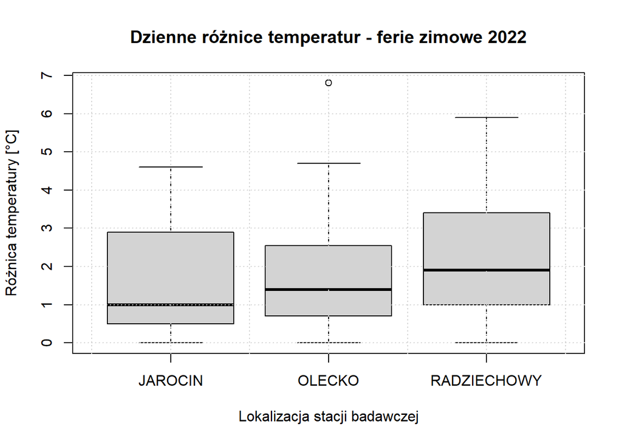

Rozkład kwartylowy w Jarocinie:

```
##   0%  25%  50%  75% 100%
## 0.00 0.50 1.00 2.85 4.60
```

Temperatura w przedziale od 0°C (0 percentyl) do 4.6°C (100 percentyl). Mediana temperatur wynosi 1 °C

Rozkład kwartylowy w Olecku:

```
##   0%  25%  50%  75% 100%
## 0.00 0.70 1.40 2.55 6.80
```

Temperatura w przedziale od 0°C do 6.8°C. Mediana wynosi 1.4°C

Rozkład kwartylowy w Radziechowach:

```
##   0%  25%  50%  75% 100%
##  0.0  1.0  1.9  3.4  5.9
```

Temperatura w przedziale od 0°C do 5.9°C. Mediana wynosi 1.9°C

**WNIOSKI:**

Najwyższą dobową różnicę temperatur odnotowano kolejno w Olecku - 6.8°C, Radziechowy 5.9°C, Jarocinie - 4.6°C, najniższa zaś w każdym z miast wynosiła 0°C.

#### Ferie zimowe - styczeń i luty rok 2023

W poniższej tabeli zestawiono różnicę maksymalnej dobowej temperatury na przestrzeni kolejnych dni w okresie ferii zimowych w roku 2023 dla poszczególnych miejscowości.

| Lokalizacja | Data | Tmax | Tdiff |
| --- | --- | --- | --- |
| JAROCIN | 2023-01-01 | 13.8 | NA |
| JAROCIN | 2023-01-02 | 14.3 | 0.5 |
| JAROCIN | 2023-01-03 | 9.9 | 4.4 |
| JAROCIN | 2023-01-04 | 6.4 | 3.5 |
| JAROCIN | 2023-01-05 | 8.9 | 2.5 |
| JAROCIN | 2023-01-06 | 6.9 | 2.0 |
| JAROCIN | 2023-01-07 | 6.4 | 0.5 |
| JAROCIN | 2023-01-08 | 4.2 | 2.2 |
| JAROCIN | 2023-01-09 | 6.9 | 2.7 |
| JAROCIN | 2023-01-10 | 5.9 | 1.0 |

[output cut: 167 more lines]

W poniższej tabeli zestawiono różnicę maksymalnej dobowej temperatury na przestrzeni kolejnych dni w okresie ferii zimowych w roku 2023.

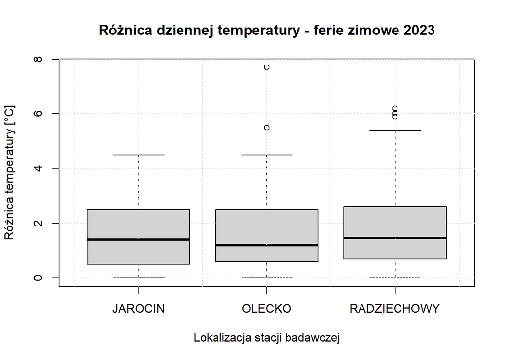

Rozkład kwartylowy w Jarocinie:

```
##   0%  25%  50%  75% 100%
## 0.00 0.58 1.40 2.50 4.50
```

Temperatura w przedziale od 0°C (0 percentyl) do 4.5°C (100 percentyl). Mediana wynosi 1.4°C

Rozkład kwartylowy w Olecku:

```
##   0%  25%  50%  75% 100%
## 0.00 0.60 1.20 2.45 7.70
```

Temperatura w przedziale od 0°C do 7.7°C. Mediana wynosi 1.2°C

Rozkład kwartylowy w Radziechowach:

```
##   0%  25%  50%  75% 100%
## 0.00 0.72 1.45 2.55 6.20
```

Temperatura w przedziale od 0°C do 6.2°C. Mediana wynosi 1.45°C

**WNIOSKI:**

Najwyższą dobową różnicę temperatur odnotowano kolejno w Olecku - 7.7, Radziechowach - 6.2°C, Jarocinie - 4.5°C, najniższa zaś w kazdym z miast wynosiła 0°C.

## Ferie zimowe - zestawienie 2022 i 2023 roku

W poniższej tabeli zestawiono różnicę maksymalnej dobowej temperatury na przestrzeni kolejnych dni w okresie ferii zimowych w latach 2022/2023.

| Lokalizacja | Data | Tmax | Tdiff |
| --- | --- | --- | --- |
| JAROCIN | 2022-01-01 | 10.4 | NA |
| JAROCIN | 2022-01-02 | 9.9 | 0.5 |
| JAROCIN | 2022-01-03 | 9.9 | 0.0 |
| JAROCIN | 2022-01-04 | 6.9 | 3.0 |
| JAROCIN | 2022-01-05 | 9.6 | 2.7 |
| JAROCIN | 2022-01-06 | 5.0 | 4.6 |
| JAROCIN | 2022-01-07 | 1.6 | 3.4 |
| JAROCIN | 2022-01-08 | 1.1 | 0.5 |
| JAROCIN | 2022-01-09 | 2.1 | 1.0 |
| JAROCIN | 2022-01-10 | -1.4 | 3.5 |

[output cut: 337 more lines]

W poniższej tabeli zestawiono różnicę maksymalnej dobowej temperatury na przestrzeni kolejnych dni w okresie ferii zimowych w roku 2022/23.

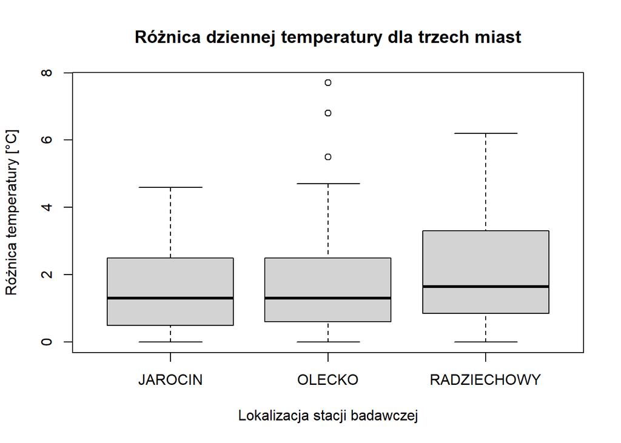

Rozkład kwartylowy w Jarocinie:

```
##   0%  25%  50%  75% 100%
##  0.0  0.5  1.3  2.5  4.6
```

Temperatura w przedziale od 0°C do 4.6°C. Mediana wynosi 1.3°C

Rozkład kwartylowy w Olecku:

```
##   0%  25%  50%  75% 100%
##  0.0  0.6  1.3  2.5  7.7
```

Temperatura w przedziale od 0°C do 7.7°C. Mediana wynosi 1.3°C

Rozkład kwartylowy w Radziechowach:

```
##   0%  25%  50%  75% 100%
## 0.00 0.88 1.65 3.30 6.20
```

Temperatura w przedziale od 0°C do 6.2°C. Mediana wynosi 1.65°C

**WNIOSKI:**

Najwyższą dobową różnicę temperatur odnotowano kolejno w Olecku 7.7, Radziechowach - 6.2°C, Jarocinie - 4.6°C, najniższa zaś w kazdym z miast wynosiła 0°C.

## Zadanie 1b

### Treść

Proszę dokładniej zbadać rozkład wahań temperatury „z dnia na dzień” w jednej wybranej lokalizacji i ocenić na ile odpowiednim modelem będzie rozkład normalny. W tym celu proszę np. oszacować parametry rozkładu normalnego i porównać graficznie histogram z funkcją gęstości rozkładu normalnego o oszacowanych parametrach.Następnie krótko ocenić sensowność następującej prostej prognozy pogody: „jutro będzie podobnie ciepło jak dziś”. Zdefiniować błąd takiej prognozy i przeanalizować wielkość tego błędu.

### Rozwiązanie

#### Dokładniejsza analiza

Do dokładniejszej analizy rozkładu wahań temperatury wybrano miasto Jarocin. Histogram wahań pokazano poniżej. Na osi x naniesiono wartości różnic temperatur między kolejnymi dniami.

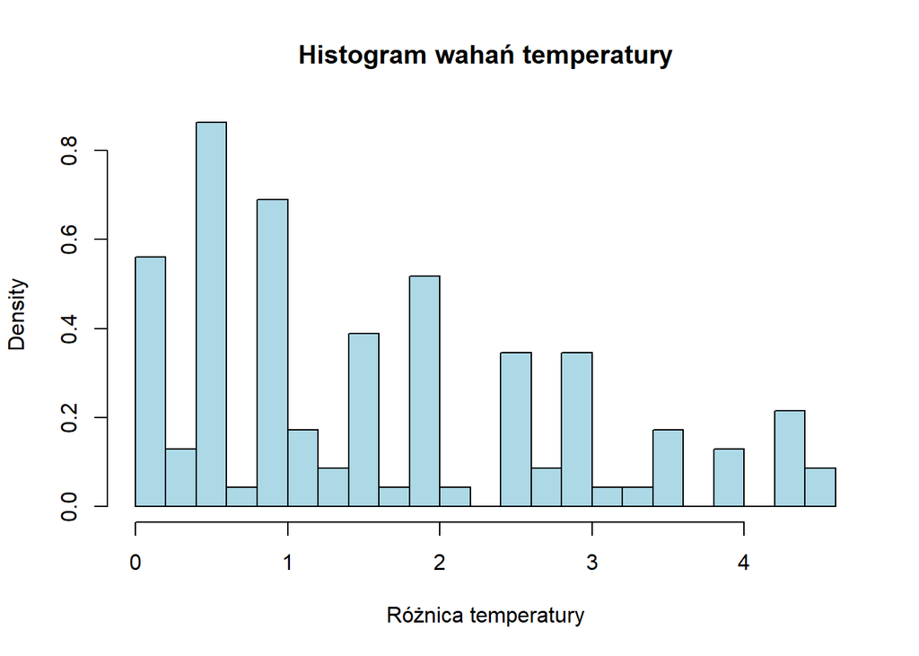

Oszacowano parametry rozkładu normalnego

```
## [1] "Wartość średnia: 1.636"
```

```
## [1] "Odchylenie standardowe: 1.278"
```

Histogram wahań temperatur wraz z naniesionym rozkładem normalnym o wyznaczonych parametrach przedstawiono poniżej:

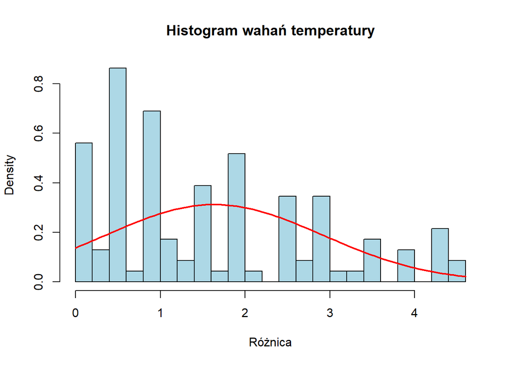

**WNIOSKI**

Analizując otrzymany wykres widać, że rozkład normalny nie jest dobrym narzędziem do modelowania danych różnic temperatur na przestrzeni badanej próbki czasowej.

Zgodnie z rozkładem normalnym widać, że najczęstsze różnice temperatur wynoszą około 1.5°C, co nie jest zgodne z danymi ukazanymi na wyskalowanym w częstości wystąpień histogramie, gdzie najczęstsza różnica wynosi okoła 0.5°C. Fakt ten może wynikać z małej ilości danych, które uwzględniono przy analizie.

#### Prognoza pogody

Posługując się jednak rozkładem normalnym można oszacować prognozę pogody na kolejny dzień. Zgodnie z regułą 3 sigm na 99,7% temperatura następnego dnia nie będzie mniejsza od -2.2°C i większa od 5.47 °C.

Do przewidywania pogody można również sie posłużyć rozkładem kwartylowym różnic temperatur w Jarocinie:

```
##   0%  25%  50%  75% 100%
##  0.0  0.5  1.3  2.5  4.6
```

Pierwszy kwartyl (Q1) wynosi 0.5 - oznacza to, że 25% najmniejszych wartości w tym zbiorze wynosi 0.5 lub mniej.

Trzeci kwartyl (Q3) wynosi 2.5 - oznacza to, że 25% największych wartości w tym zbiorze wynosi 2.5 lub więcej.

Warto zauważyć, że rozpiętość między Q1 a Q3, czyli tzw. rozstęp ćwiartkowy (interquartile range, IQR), wynosi 2.0, co oznacza, że 50% wartości mieści się w tym przedziale.

Dzięki rozkładowi kwartylowemu możemy szacować z jakim prawdopodobieństwem temperatura następnego dnia będzie różnić się od temperatury z dnia poprzedniego.

Można pokusić się o stwierdzenie, ze dnia następnego temperatura najprawdopodobniej będzie się róznić od temperatury dnia poprzedniego o 1,3°C

# Problem 2

Problem drugi polegał na sprawdzeniu, czy na przestrzeni lat widoczny jest zjawisko globalnego ocieplenia.

Zjawisko globalnego ocieplenia jest to proces, w którym zwiększające się ilości gazów cieplarnianych, takich jak dwutlenek węgla, magazunują ciepło w atmosferze ziemskiej, powodując wzrost temperatury powierzchniowej. Efektem globalnego ocieplenia są zmiany klimatyczne, takie jak wzrost poziomu morza, ekstremalne zjawiska pogodowe i zagrożenia dla różnych ekosystemów i gatunków. Wielu naukowców uważa, że główną przyczyną globalnego ocieplenia jest działalność człowieka, w szczególności emisja gazów cieplarnianych związana z przemysłem i transportem.

### Treść

Wykorzystując dostępne dane pogodowe z problemu 1 (np. z jednej lokalizacji, ale z wielu lat) proszę wyszukać te, które (do wyboru): a) świadczą za ociepleniem klimatu, b) świadczą przeciw ociepleniu klimatu,

,a następnie przygotować krótką prezentację (1 lub 2 slajdy) mającą przekonać słuchaczy, że ocieplenie klimatu jest widoczne/niewidoczne w danych pomiarowych.

### Rozwiązanie

**Argument 1**

Już na podstawie pierwszej części projektu jesteśmy w stanie zauważyć niewielki wzrost średniej wartości temperatury na przestrzeni roku w okresie ferii zimowych. Mianowicie analizując poniższe tabele z poprzedniego zadania widać, że średnia temperatura w styczniu i lutym 2023 roku w porównaniu do roku poprzedniego wzrostła o 0.4°C dla Radziechowa, 0.1°C dla Olecka i 0.1°C dla Jarocina.

Średnia temperatura powietrza w okresie ferii zimowych - rok 2022

| Lokalizacja | mean_temp |
| --- | --- |
| JAROCIN | 4.6 |
| OLECKO | 2.5 |
| RADZIECHOWY | 4.8 |

Średnia temperatura powietrza w okresie ferii zimowych - rok 2023

| Lokalizacja | mean_temp |
| --- | --- |
| JAROCIN | 4.7 |
| OLECKO | 2.6 |
| RADZIECHOWY | 5.2 |

Nieznaczny wzrost średniej temperatury na przestrzeni zaledwie roku może świadczyć o pewnym ociepleniu klimatu.

**Argument 2**

Zestawiono wszystkie dane wykorzystane w tej części projektu :

| Numer | Lokalizacja | Rok | Miesiac | Dzien | Tmax | Status.pomiaru.Tmax | Tmin | Status.pomiaru.Tmin | Tavg | Status.pomiaru.Tavg | TMNG | Status.pomiaru.TMNG | SMDB | Status.pomiaru.SMDB | Rodzaj.opadu...S.W... | PKSN | Status.pomiaru.PKSN |
| --- | --- | --- | --- | --- | --- | --- | --- | --- | --- | --- | --- | --- | --- | --- | --- | --- | --- |
| 249220040 | DYN\xd3W | 1951 | 1 | 1 | 0.6 | NA | -8.5 | NA | -0.6 | NA | 0.0 | 8 | 0.0 | 9 |  | 0 | 9 |
| 249220040 | DYN\xd3W | 1951 | 1 | 2 | 4.2 | NA | -0.4 | NA | 2.2 | NA | 0.0 | 8 | 0.0 | 9 |  | 0 | 9 |
| 249220040 | DYN\xd3W | 1951 | 1 | 3 | 3.2 | NA | -2.4 | NA | -0.8 | NA | 0.0 | 8 | 0.0 | 9 |  | 0 | 9 |
| 249220040 | DYN\xd3W | 1951 | 1 | 4 | 3.6 | NA | -5.4 | NA | 1.6 | NA | 0.0 | 8 | 0.0 | 9 |  | 0 | 9 |
| 249220040 | DYN\xd3W | 1951 | 1 | 5 | 2.6 | NA | -0.4 | NA | 1.6 | NA | 0.0 | 8 | 0.0 | 9 |  | 0 | 9 |
| 249220040 | DYN\xd3W | 1951 | 1 | 6 | 3.0 | NA | 1.3 | NA | 2.0 | NA | 0.0 | 8 | 0.0 | 9 |  | 0 | 9 |
| 249220040 | DYN\xd3W | 1951 | 1 | 7 | 4.0 | NA | 1.1 | NA | 2.8 | NA | 0.0 | 8 | 0.0 | 9 |  | 0 | 9 |
| 249220040 | DYN\xd3W | 1951 | 1 | 8 | 3.3 | NA | 0.6 | NA | 2.8 | NA | 0.0 | 8 | 3.2 | NA | W | 0 | 9 |
| 249220040 | DYN\xd3W | 1951 | 1 | 9 | 5.0 | NA | 2.1 | NA | 3.8 | NA | 0.0 | 8 | 0.0 | 9 |  | 0 | 9 |
| 249220040 | DYN\xd3W | 1951 | 1 | 10 | 4.1 | NA | -0.9 | NA | 0.9 | NA | 0.0 | 8 | 0.0 | 9 |  | 0 | 9 |

[output cut: 9990 more lines]

#### Graficzne prezentacjia zmian temperatury w sezonie ferii zimowych na przestrzeni lat 1951-2000**

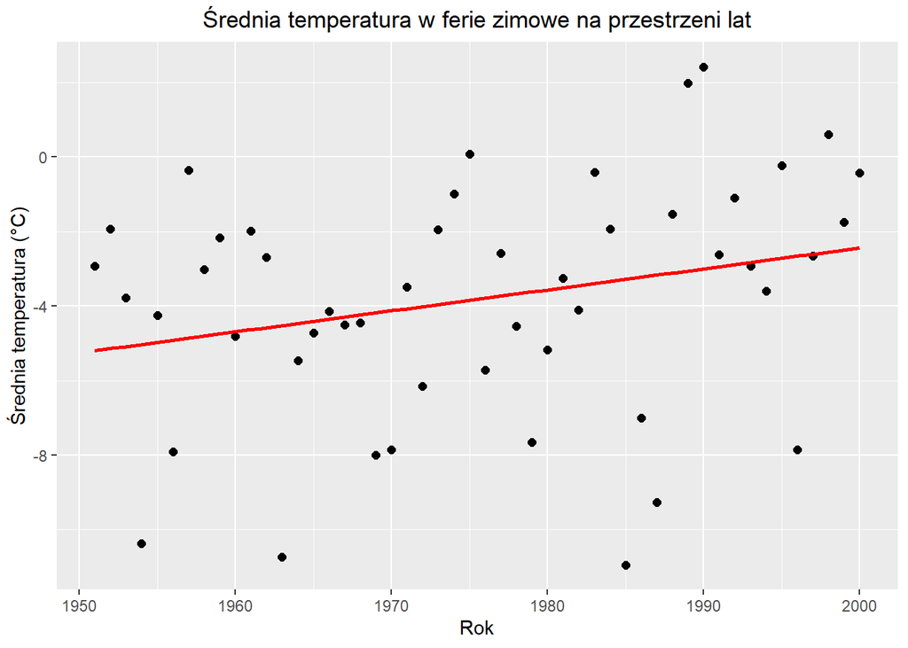

Dodano linię trendu średnich temperatur, która potwierdza założoną hipotezę o ociepleniu klimetu na przestrzeni lat.

Równanie prostej regresji jest następujące:

```
## [1] "y = -115.18772424631 + 0.0563757964202638 * x"
```

Oznacza to, że w przeciągu niespełna 50 lat średnia temperatura otoczenia w Szepietowie przypadająca na miesiąc styczeń wzrosła aż o : 2.82°C.

**WNIOSKI**

Po zapoanianiu się z powyższymi argumentami i przeanalizwaniu zaprezentownych wykresów można stwierdzić, że średnia temperatura powietrza na przestrzni lat wzrosła, co świadczy o pogłębiającym się zjawisku globalnego ocieplenia.

# Problem 3 - Sygnał z detektora promieniowania gamma

W zadaniu 3 na podstawie danych zapisanych w formie binarnej określających sygnał z detektora promieniowania gamma przeprowadzono 2 analizy czasów wystąpienia impulsów w celu określenia liczby impulsów oraz odstępów między sąsiednimi impulsami w wybranej jednostce czasu.

Częstotliowość próbkowania sygnału wynosi 50MHz.

### Treść

W dostępnym sygnale z detektora promieniowania gamma wyszukać impulsy i przeprowadzić analizę statystyczną czasów wystąpienia impulsów, w szczególności zbadać rozkłady:  
1. liczby impulsów w wybranej jednostce czasu  
2. odstępy między sąsiednimi impulsami.

### Rozwiązanie

Na poczatku wczytano plik z danymi do wektora, zaś do dalszych badań wykorzystano jedynie przedział [30000000,35000000]. Badany przedział wygląda następująco:

#### Analiza liczby impulsów w wybranej jednostce czasu

Zdecydowano się przeanalizować liczbę impulsów dla chwili czasowej od 30000000 do 35000000, zatem okres czasu wynosił 5mln jednostek.

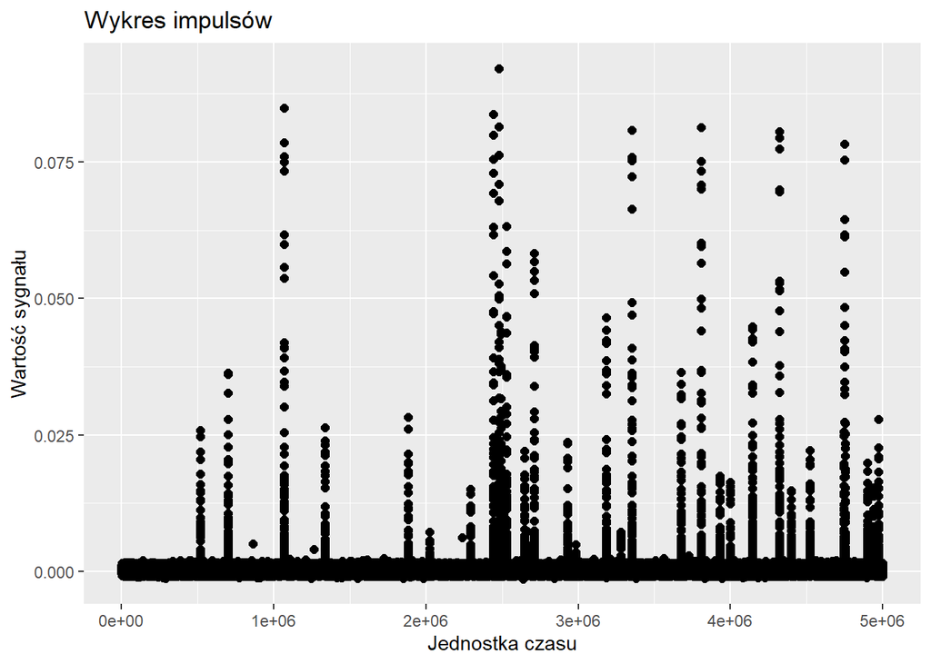

```
## Wartość szczytowa sygnału: 0.09212263
```

```
## Wartość minimalna sygnału: -0.001313689
```

Przefiltrowany wykres sygnałów pokazano poniżej. Przyjęto wartość progową odróżniająca szumy od sygnałów na poziomie 0.02.

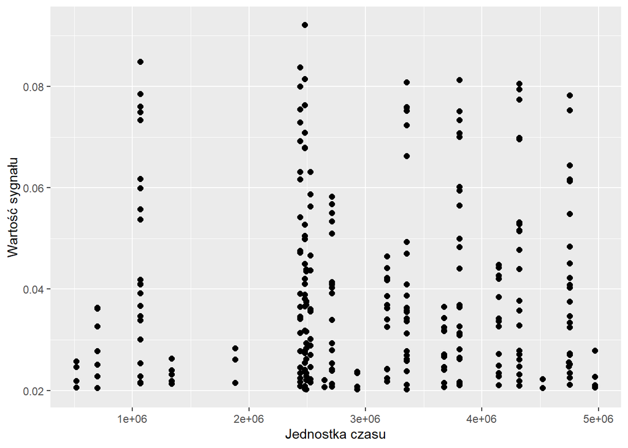

Przy określania liczby impulsów założono, że w momencie pojawienia się impulsu nie bada się już wartości sygnału dla następnych 500 jednostek czasowych z uwagi na to, że będą one reprezentować wartości tego samego impulsu. Liczba sygnałów w wybranej jednostce czasu wynosiła zatem:

```
## [1] 22
```

Dystrybucja liczby impulsów w czasie:

```
##  [1] 0 2 2 1 3 4 2 2 2 4
```

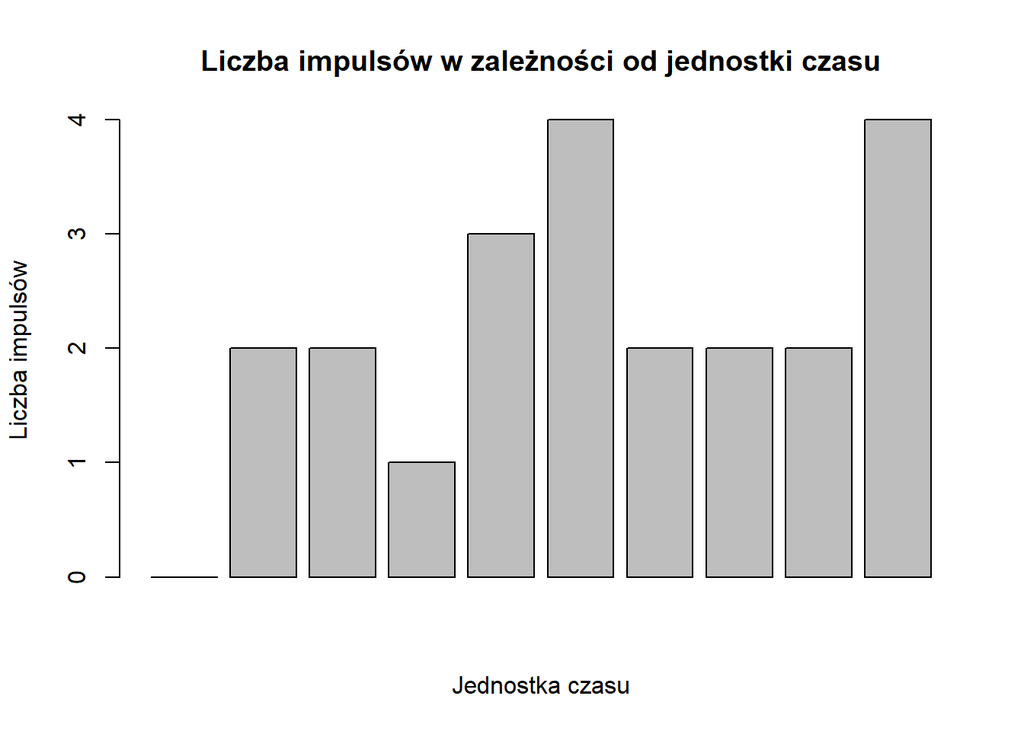

Badany przedział, w którym odnotowano 22 impulsy podzielono na 10 mniejszych przedziałów. Zsumowano ile impulsów występowało w każdym z przedziałów. Następnie pogrupowano te przedziały względem liczby wystąpień impulsów. Poniższy wykres przedstawia tę zależność.

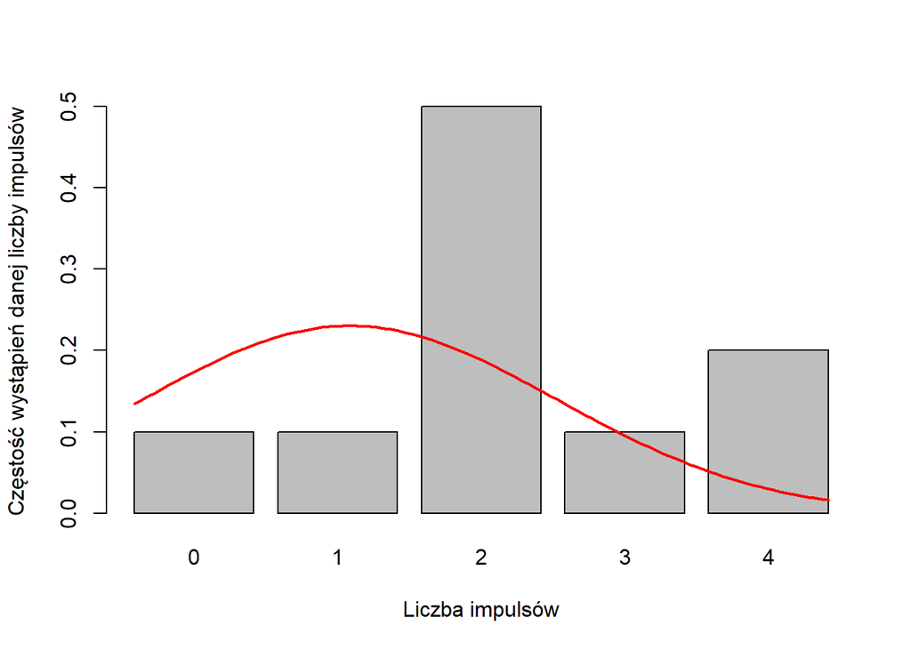

```
## [1] 2
```

Odchylenie standardowe:

```
## [1] 1.732051
```

Próba aproksymacji wykresu rozkładem normalnym okazała się być słabym pomysłem. W celu uzyskania sensowniejszego wykresu należało skorzystać z innego narzędzia języka R.

Parametry rozkładu Poissona dla wybranych danych:

```
## Fitting of the distribution ' pois ' by maximum likelihood
## Parameters:
##        estimate Std. Error
## lambda      2.2  0.4690415
```

Wykres z naniesionymi wartościami dyskretnego rozkładu Poissona.

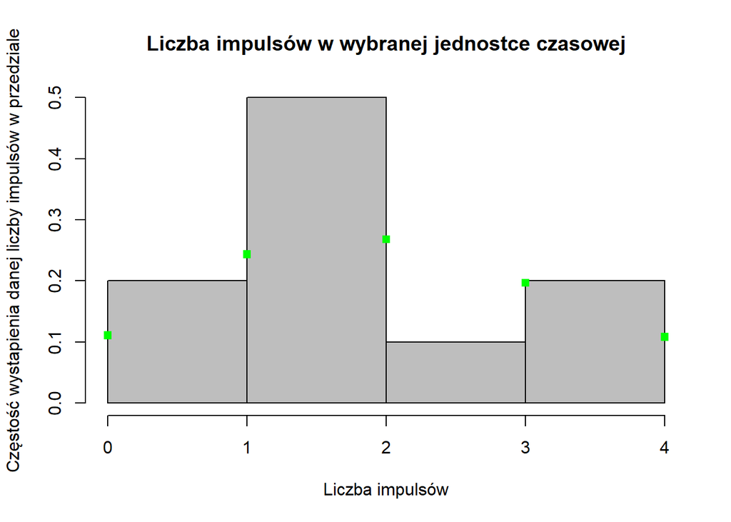

Średnia liczba wystąpień impulsów dla wybranego przedziału wyniosła:

```
## [1] 4.4e-06
```

#### Analiza odstępów między sąsiednimi impulsami wybranej jednostce czasu

Liczba wszystkich impulsów w całej próbie wyniosła:

```
## [1] 291
```

Rozkład odstępów czasowych między impulsami (wykres przy wykorzystaniu ggplot)

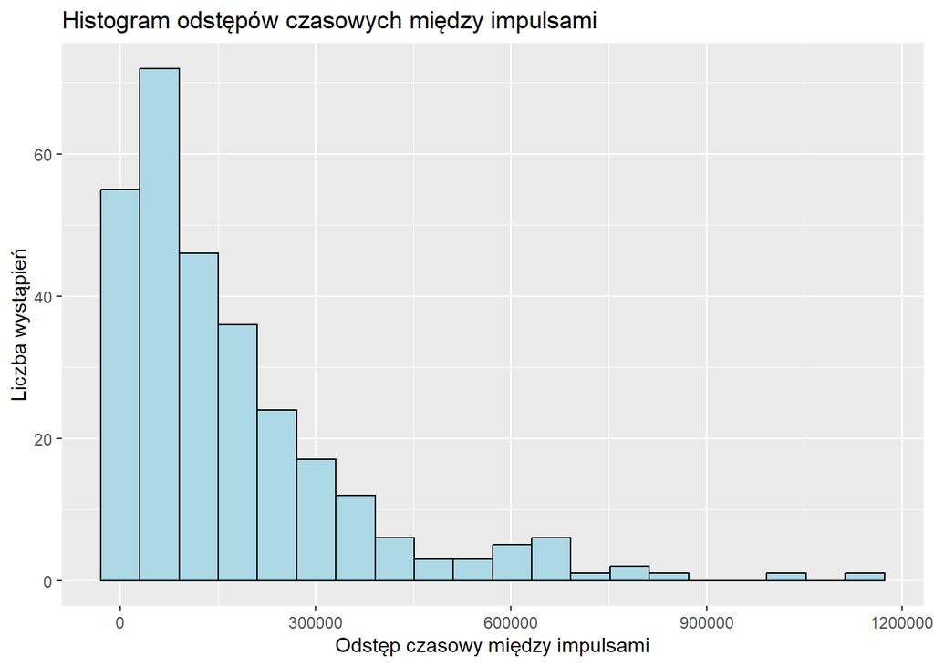

Modyfikując powyższy wykres (przez dobór innej skali i inny podział na odstępy czasowe między impulsami) tak, aby móc go dopasować do rozkładu wykładniczego, korzystając z innego narzędzia języka R otrzymano poniższy wykres z następującym parametrem rozkładu lambda:

```
##        rate
##   5.820022e-06
##  (3.411758e-07)
```

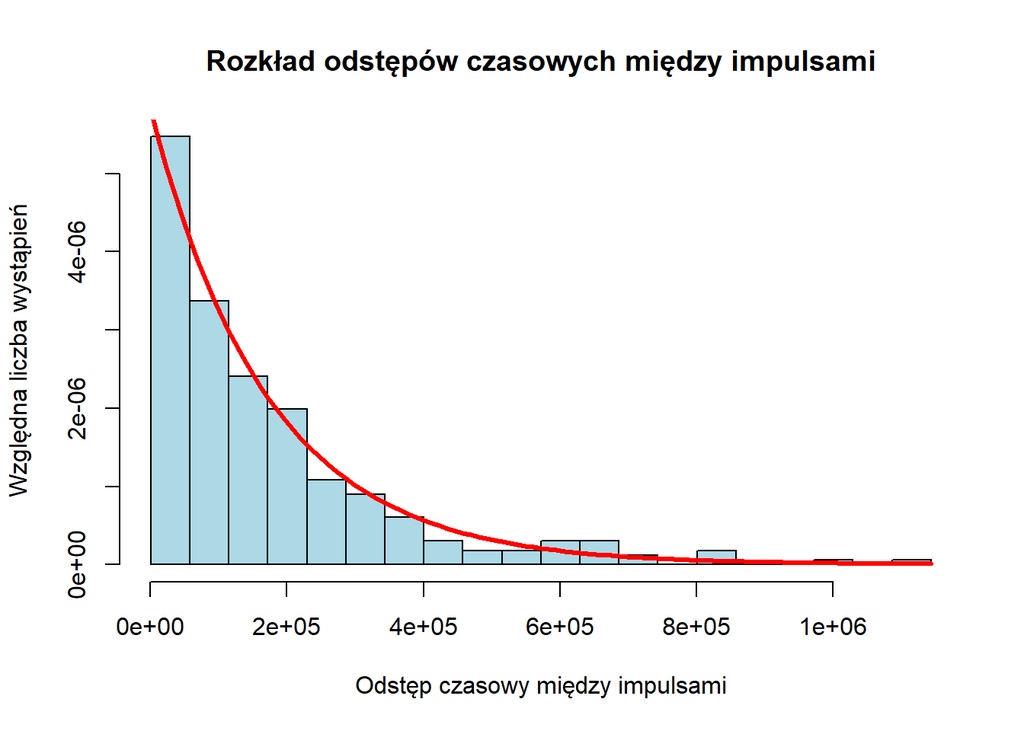

Wykres pokazuje częstość wystąpień impulsów w zależności od odległości od poprzedniego impulsu.